# Using GRASS for stream-network extraction and basins delineation - osboxes

Methodological procedure described in:

[Amatulli, Giuseppe, et al. “Hydrography90m: A new high-resolution global hydrographic dataset.” Earth System Science Data Discussions 2022 (2022): 1-43.](https://essd.copernicus.org/articles/14/4525/2022/essd-14-4525-2022.html)

```
mkdir -p /$HOME/my_SE_data/exercise
cd /$HOME/my_SE_data/exercise
wget https://raw.githubusercontent.com/selvaje/SE_docs/master/source/GRASS/grass_hydro.ipynb
jupyter-lab /$HOME/my_SE_data/exercise/grass_hydro.ipynb
```

## Theoretical background

The first step towards modeling hydrological features is delineating a comprehensive hydrography network. DEMs at different spatial resolutions allow for the identification of stream channels, using a variety of flow-routing algorithms. Such algorithms are based on the observation that water follows the steepest and shortest route along a relief, and accumulates in valleys, lowlands, flat areas and depressions. Several algorithms have been proposed for stream network routing. These algorithms proceed in several stages: determining flow directions, resolving depressions and flat areas, and finally, calculating flow accumulation.

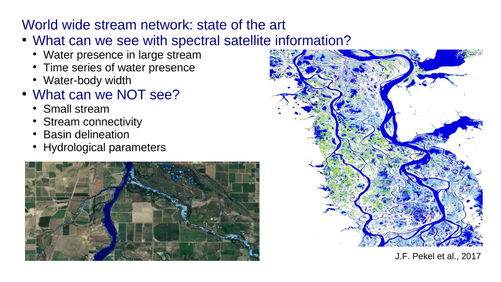

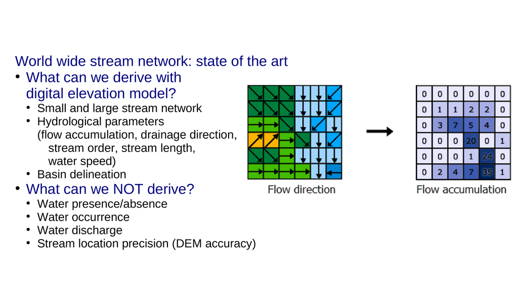

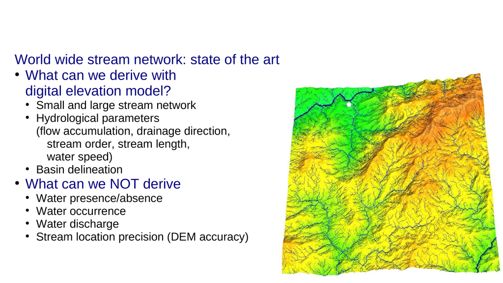

## Methodology

Below we describe how we will extract a new high-resolution hydrography (stream-network and basins) from the 1KM DEM. In this exercise we simulate a case that we can not run the full South America continent in one tile because we reach RAM limitation. Therefore we compute the analysis in 3 tiles and then we combine the results.

We are going to use 3 GRASS commands:

- [r.watershed](https://grass.osgeo.org/grass82/manuals/r.watershed.html) to derive flow accumulation
- [r.stream.extract](https://grass.osgeo.org/grass82/manuals/r.stream.extract.html) to extract-stream network
- [r.stream.basins](https://grass.osgeo.org/grass82/manuals/addons/r.stream.basins.html) to delineate basins

**Flow direction algorithms**

In r.watershed there are 2 flow direction algorithms.

- SFD: single flow direction (O’Callaghan, 1984). SFD concentrates the flow in only one downslope cell.
- MFD: multiple flow direction (Holmgren, 1994). MFD distributites the flow among several downslope neighboring cells. The proportion of flow directed to each neighbor is determined based on the gradient or slope towards those cells.

Lectures: [Flow Metrics](http://spatial-ecology.net/docs/source/lectures/lect_20210518_flow_metrics.pdf)

**Prepare GRASS for hydrography extraction**

Considering that GRASS can not working properly under */media/sf_LVM_shared/my_SE_data/* therefore we create a working copy of the *SE_data* under */home/osboxes/my_SE_data/*

Follow the code lines in the box below and use the g.extension to install the add-on extension:

```
g.extension extension=r.stream.basins
```

```bash
%%bash

mkdir -p /$HOME/my_SE_data/exercise
cp -r /$HOME/SE_data/exercise/grassdb /$HOME/my_SE_data/exercise
cd /$HOME/my_SE_data/exercise

# install the GRASS add-on r.stream.basins

grass --text grassdb/europe/PERMANENT/ <<EOF
g.extension extension=r.stream.basins
EOF
```

```
Starting GRASS GIS...

          __________  ___   __________    _______________
         / ____/ __ \/   | / ___/ ___/   / ____/  _/ ___/
        / / __/ /_/ / /| | \__ \\_  \   / / __ / / \__ \
       / /_/ / _, _/ ___ |___/ /__/ /  / /_/ // / ___/ /
       \____/_/ |_/_/  |_/____/____/   \____/___//____/

Welcome to GRASS GIS 8.4.2
GRASS GIS homepage:                      https://grass.osgeo.org
This version running through:            Bash Shell (/bin/bash)
Help is available with the command:      g.manual -i
See the licence terms with:              g.version -c
See citation options with:               g.version -x
Start the GUI with:                      g.gui wxpython
When ready to quit enter:                exit

Fetching <r.stream.basins> from <https://github.com/OSGeo/grass-addons/>
(be patient)...
```

**Inputs dataset**

We are going to use the following dataset:

- DEM at 1km resolution
- A raster grid-cell area. Each grid-cell reports the values in km^2 (produced with the [r.cell.area add-on](https://grass.osgeo.org/grass83/manuals/addons/r.cell.area.html))
- A raster land-sea mask labeled as 1-0
- A raster depression labeles as 1-0
- A shapefile reporting the 3 tiles

```python
! gdal_translate -r near -tr  0.08333333333333 -0.08333333333333   /media/sf_LVM_shared/my_SE_data/exercise/geodata/mask/msk_1km.tif /tmp/msk_1km.tif
```

```
Input file size is 43200, 17400
0...10...20...30...40...50...60...70...80...90...100 - done.
```

```python
import rasterio
import matplotlib.pyplot as plt

# 1. Open the file
with rasterio.open("/tmp/msk_1km.tif") as src:
    # Read the data without masking the zeros
    # using overview_level to keep RAM tiny
    data = src.read(1, masked=False)

    # Grab the geographical coordinates for the axes
    extent = [src.bounds.left, src.bounds.right, src.bounds.bottom, src.bounds.top]

# 2. Plot it with boosted contrast
plt.figure(figsize=(12, 6))

# Option A: Force the color limits to tightly span 0 to 1
# This makes 0 = pure black and 1 = pure white
plt.imshow(data, cmap='gray', vmin=0, vmax=1, extent=extent)

# Option B: Alternatively, use a vibrant colormap if you prefer color over grayscale:
# plt.imshow(data, cmap='viridis', vmin=0, vmax=1, extent=extent)

plt.xlabel("Longitude")
plt.ylabel("Latitude")
plt.title("World Mask (High Contrast View)")
plt.show()
```

[figure not shown]

```python
# digital elevation model
dem = rasterio.open("/media/sf_LVM_shared/my_SE_data/exercise/geodata/dem/SA_elevation_mn_GMTED2010_mn_msk.tif")
show(dem)
```

[figure not shown]

```python
# area grid-cell in km^2
area = rasterio.open("/media/sf_LVM_shared/my_SE_data/exercise/geodata/dem/SA_are_1km_msk.tif")
show(area)
```

[figure not shown]

**Tiling system**

Due to the memory limitation of the [r.watershed](https://grass.osgeo.org/grass82/manuals/r.watershed.html) module (2 billion (2^31 - 1) cells), we will need to work in tiles. Each tile should be able to include the maximum number of entire basins.

```python
# tiles
import geopandas as gpd
gdf = gpd.read_file('/media/sf_LVM_shared/my_SE_data/exercise/geodata/shp/tilesComp.shp')
print (gdf)
gdf.plot(edgecolor="purple", facecolor="None")
```

```
   id dimension Continent  CropW  CropS  CropE  CropN  \
0   1     30x49        SA    0.6    0.0    2.0    2.0
1   2     40x37        SA    2.8    2.8    0.0    2.8
2   3     40x37        SA    0.3    2.8    2.8    0.0

                                            geometry
0  POLYGON ((-76.40000 -12.00000, -43.00000 -12.0...
1  POLYGON ((-73.90000 1.00000, -34.60000 1.00000...
2  POLYGON ((-81.70000 12.70000, -41.70000 12.700...
```

[figure not shown]

```python
display(gdf)
```

|  | id | dimension | Continent | CropW | CropS | CropE | CropN | geometry |
| --- | --- | --- | --- | --- | --- | --- | --- | --- |
| 0 | 1 | 30x49 | SA | 0.6 | 0.0 | 2.0 | 2.0 | POLYGON ((-76.40000 -12.00000, -43.00000 -12.0... |
| 1 | 2 | 40x37 | SA | 2.8 | 2.8 | 0.0 | 2.8 | POLYGON ((-73.90000 1.00000, -34.60000 1.00000... |
| 2 | 3 | 40x37 | SA | 0.3 | 2.8 | 2.8 | 0.0 | POLYGON ((-81.70000 12.70000, -41.70000 12.700... |

**First run: compute MFD flow accumulation for each tile**

The final aim of this script session is to produce a seamless flowaccomulation for the full South America.

```bash
%%bash

cd /media/sf_LVM_shared/my_SE_data/exercise

# use the --tmp-location option to store a temporal location in the /tmp folder

grass --text --tmp-project /media/sf_LVM_shared/my_SE_data/exercise/geodata/dem/SA_elevation_mn_GMTED2010_mn_msk.tif  <<'EOF'

g.gisenv set="GRASS_VERBOSE=-1","DEBUG=0"

## import the layers
r.external input=/media/sf_LVM_shared/my_SE_data/exercise/geodata/dem/SA_elevation_mn_GMTED2010_mn_msk.tif output=elv --o --q # dem
r.external input=/media/sf_LVM_shared/my_SE_data/exercise/geodata/dem/SA_all_dep_1km.tif                   output=dep --o --q # depression
r.external input=/media/sf_LVM_shared/my_SE_data/exercise/geodata/dem/SA_are_1km_msk.tif                   output=are --o --q # area-pixel
r.external input=/media/sf_LVM_shared/my_SE_data/exercise/geodata/mask/msk_1km.tif                         output=msk --o --q # land-ocean mask

g.region  -m

for tile in 1 2 3  ; do     # loop for each tile
r.mask raster=msk --o --q   # usefull to mask the flow accumulation

# extract tile extent from the  tilesComp.shp
wL=$(ogrinfo -al -where  " id  = '$tile' " /media/sf_LVM_shared/my_SE_data/exercise/geodata/shp/tilesComp.shp | grep POLYGON | awk '{ gsub(/[(()),]/," ",$0 ); print $2 }')
nL=$(ogrinfo -al -where  " id  = '$tile' " /media/sf_LVM_shared/my_SE_data/exercise/geodata/shp/tilesComp.shp | grep POLYGON | awk '{ gsub(/[(()),]/," ",$0 ); print $3 }')
eL=$(ogrinfo -al -where  " id  = '$tile' " /media/sf_LVM_shared/my_SE_data/exercise/geodata/shp/tilesComp.shp | grep POLYGON | awk '{ gsub(/[(()),]/," ",$0 ); print $4 }')
sL=$(ogrinfo -al -where  " id  = '$tile' " /media/sf_LVM_shared/my_SE_data/exercise/geodata/shp/tilesComp.shp | grep POLYGON | awk '{ gsub(/[(()),]/," ",$0 ); print $7 }')

g.region w=$wL  n=$nL  s=$sL  e=$eL  res=0:00:30   --o
g.region -m

### maximum ram 66571M  for 2^31 -1   (2 147 483 647 cell)  / 1 000 000  * 31 M
####  -m  Enable disk swap memory option: Operation is slow
####  -b Beautify flat areas
####   threshold=1  = ~1 km2 = 0.9  m2

echo "############# compute the flow accumulation using MFD for tile $tile ##############"
r.watershed  -b  elevation=elv  depression=dep  accumulation=flow drainage=dir_rw flow=are   memory=2000 --o --q

echo "############# extract stream ##################"
r.stream.extract elevation=elv accumulation=flow depression=dep threshold=8 direction=dir_rs stream_raster=stream  memory=2000 --o --q

echo "############# delineate basin  ##################"
r.stream.basins -l  stream_rast=stream direction=dir_rs   basins=lbasin  memory=2000 --o  --q
r.colors -r stream --q ; r.colors -r lbasin --q ; r.colors -r flow --q

r.out.gdal --o -c -m  createopt="COMPRESS=DEFLATE,ZLEVEL=9" type=UInt32 format=GTiff nodata=0 input=lbasin output=/media/sf_LVM_shared/my_SE_data/exercise/geodata/dem/lbasinTmp1_$tile.tif

echo "###### create a small zone flow binary for later use ###########"
r.mapcalc " small_zone_flow =   if( !isnull(flow) && isnull(lbasin) , 1 , null()) " --o  --q

echo "##### create a smaller box ########"
CropW=$( ogrinfo -al   -where  " id  = '$tile' " /media/sf_LVM_shared/my_SE_data/exercise/geodata/shp/tilesComp.shp  | grep " CropW" | awk '{  print $4 }' )
CropE=$( ogrinfo -al   -where  " id  = '$tile' " /media/sf_LVM_shared/my_SE_data/exercise/geodata/shp/tilesComp.shp  | grep " CropE" | awk '{  print $4 }' )
CropS=$( ogrinfo -al   -where  " id  = '$tile' " /media/sf_LVM_shared/my_SE_data/exercise/geodata/shp/tilesComp.shp  | grep " CropS" | awk '{  print $4 }' )
CropN=$( ogrinfo -al   -where  " id  = '$tile' " /media/sf_LVM_shared/my_SE_data/exercise/geodata/shp/tilesComp.shp  | grep " CropN" | awk '{  print $4 }' )

nS=$(g.region -m  | grep ^n= | awk -F "=" -v CropN=$CropN  '{ printf ("%.14f\n" , $2 - CropN ) }' )
sS=$(g.region -m  | grep ^s= | awk -F "=" -v CropS=$CropS  '{ printf ("%.14f\n" , $2 + CropS ) }' )
eS=$(g.region -m  | grep ^e= | awk -F "=" -v CropE=$CropE  '{ printf ("%.14f\n" , $2 - CropE ) }' )
wS=$(g.region -m  | grep ^w= | awk -F "=" -v CropW=$CropW  '{ printf ("%.14f\n" , $2 + CropW ) }' )

# set a smaller region to avoid border effect
g.region w=$wS  n=$nS  s=$sS  e=$eS  res=0:00:30  save=smallext --o  --q # smaller region
g.region region=smallext --o --q
g.region  -m

# at this point we want remove all no-entire basins. To do this we create 4 stripes of 1 pixel allong the tile borders.

echo "######## left stripe ########"
eST=$(g.region -m  | grep ^e= | awk -F "=" '{ print $2 }')
wST=$(g.region -m  | grep ^e= | awk -F "=" '{ printf ("%.14f\n" , $2 - ( 1 *  0.00833333333333 )) }' )

g.region n=$nS s=$sS     e=$eST w=$wST  res=0:00:30 --o
r.mapcalc " lbasin_wstripe = lbasin " --o --q
g.region region=smallext --o --q

echo "######## right stripe  ########"
wST=$(g.region -m  | grep ^w= | awk -F "=" '{ print $2   }' )
eST=$(g.region -m  | grep ^w= | awk -F "=" '{ printf ("%.14f\n" , $2 + ( 1 *  0.00833333333333 )) }' )

g.region n=$nS s=$sS  e=$eST w=$wST  res=0:00:30 --o
r.mapcalc " lbasin_estripe    = lbasin " --o --q

g.region region=smallext --o --q
echo "######## top stripe   ########"
nST=$(g.region -m  | grep ^n= | awk -F "=" '{ print $2   }' )
sST=$(g.region -m  | grep ^n= | awk -F "=" '{ printf ("%.14f\n" , $2 - ( 1 *  0.00833333333333 )) }' )

g.region e=$eS w=$wS n=$nST s=$sST res=0:00:30  --o
r.mapcalc " lbasin_nstripe    = lbasin " --o --q
g.region region=smallext --o --q

echo "######## bottom stripe ########"
sST=$(g.region -m  | grep ^s= | awk -F "=" '{ print $2   }' )
nST=$(g.region -m  | grep ^s= | awk -F "=" '{ printf ("%.14f\n" , $2 + ( 1 *  0.00833333333333 )) }' )

g.region   e=$eS  w=$wS  n=$nST  s=$sST  res=0:00:30 --o
r.mapcalc " lbasin_sstripe    = lbasin " --o --q
g.region region=smallext   --o --q

# the 1 pixel strip is used to have

echo "######## remove incompleate basins  ########"
    cat <(r.report -n -h units=c map=lbasin_estripe | awk  '{ gsub ("\\|"," " ) ; { print $1 }   } ' | awk  '$1 ~ /^[0-9]+$/ { print $1 } '   ) \
        <(r.report -n -h units=c map=lbasin_wstripe | awk  '{ gsub ("\\|"," " ) ; { print $1 }   } ' | awk  '$1 ~ /^[0-9]+$/ { print $1 } '   ) \
        <(r.report -n -h units=c map=lbasin_sstripe | awk  '{ gsub ("\\|"," " ) ; { print $1 }   } ' | awk  '$1 ~ /^[0-9]+$/ { print $1 } '   ) \
        <(r.report -n -h units=c map=lbasin_nstripe | awk  '{ gsub ("\\|"," " ) ; { print $1 }   } ' | awk  '$1 ~ /^[0-9]+$/ { print $1 } '   ) \
        <(r.report -n -h units=c map=lbasin         | awk  '{ gsub ("\\|"," " ) ; { print $1 }   } ' | awk  '$1 ~ /^[0-9]+$/ { print $1 } ' ) \
      | sort  | uniq -c | awk '{ if($1==1) {print $2"="$2 } else { print $2"=NULL"}  }' >  /tmp/lbasin_${tile}_reclass.txt

r.reclass input=lbasin  output=lbasin_rec   rules=/tmp/lbasin_${tile}_reclass.txt   --o --q
rm -f /tmp/lbasin_${tile}_reclass.txt

r.mapcalc  " lbasin_clean = lbasin_rec" --o --q
g.remove -f  type=raster name=lbasin_rec,lbasin_estripe,lbasin_wstripe,lbasin_nstripe,lbasin_sstripe --q

echo "############  export basin only for visual inspection  ############"

r.mask raster=lbasin_clean --o --q
r.out.gdal --o -c -m  createopt="COMPRESS=DEFLATE,ZLEVEL=9" type=UInt32 format=GTiff nodata=0 input=lbasin_clean  output=/media/sf_LVM_shared/my_SE_data/exercise/geodata/dem/lbasinTmp2_$tile.tif

echo "############ output the flow accumulation  ############"
r.mask raster=msk --o --q

r.mapcalc  " lbasin_flow_clean  = if ( !isnull(lbasin_clean ) || !isnull(small_zone_flow) , 1 , null()  ) " --o --q
r.grow  input=lbasin_flow_clean  output=lbasin_flow_clean_grow  radius=4  --o --q
r.mask  raster=lbasin_flow_clean_grow   --o --q

r.out.gdal --o -f -c -m createopt="COMPRESS=DEFLATE,ZLEVEL=9"  nodata=-9999999  type=Float32 format=GTiff input=flow output=/media/sf_LVM_shared/my_SE_data/exercise/geodata/dem/flow_${tile}.tif

gdal_edit.py -a_ullr  $wS $nS $eS $sS  /media/sf_LVM_shared/my_SE_data/exercise/geodata/dem/flow_${tile}.tif
gdal_edit.py -tr 0.00833333333333333333333333333333333 -0.00833333333333333333333333333333333  /media/sf_LVM_shared/my_SE_data/exercise/geodata/dem/flow_${tile}.tif

done

EOF
```

[output not shown]

[output not shown]

```
projection=3
zone=0
n=14
s=-56
w=-83
e=-34
nsres=923.44150551
ewres=703.7149865
rows=8400
cols=5880
cells=49392000
projection=3
zone=0
n=-12
s=-56
w=-76.4
e=-43
nsres=924.52244935
ewres=710.89449752
rows=5280
cols=4008
cells=21162240
############# compute the flow accumulation using MFD for tile 1 ##############
############# extract stream ##################
############# delineate basin  ##################
```

```
WARNING: Color table of raster map <stream> not found
Checking GDAL data type and nodata value...

Using GDAL data type <UInt32>
Exporting raster data to GTiff format...
WARNING: Too many values, color table cut to 65535 entries

r.out.gdal complete. File
</media/sf_LVM_shared/my_SE_data/exercise/geodata/dem/lbasinTmp1_1.tif>
created.
```

```
###### create a small zone flow binary for later use ###########
##### create a smaller box ########
projection=3
zone=0
n=-14
s=-56
w=-75.8
e=-45
nsres=924.64630106
ewres=707.62000721
rows=5040
cols=3696
cells=18627840
######## left stripe ########
######## right stripe  ########
######## top stripe   ########
######## bottom stripe ########
######## remove incompleate basins  ########
```

```
############  export basin only for visual inspection  ############
```

```
WARNING: MASK already exists and will be overwritten
Checking GDAL data type and nodata value...

Using GDAL data type <UInt32>
Exporting raster data to GTiff format...
WARNING: Too many values, color table cut to 65535 entries

r.out.gdal complete. File
</media/sf_LVM_shared/my_SE_data/exercise/geodata/dem/lbasinTmp2_1.tif>
created.
```

```
############ output the flow accumulation  ############
```

```
WARNING: MASK already exists and will be overwritten
WARNING: MASK already exists and will be overwritten
WARNING: Precision loss: Float32 can not preserve the DCELL precision of
         raster <flow>. This can be avoided by using Float64
WARNING: Forcing raster export
Checking GDAL data type and nodata value...

Using GDAL data type <Float32>
Exporting raster data to GTiff format...
WARNING: Too many values, color table cut to 65535 entries

r.out.gdal complete. File
</media/sf_LVM_shared/my_SE_data/exercise/geodata/dem/flow_1.tif> created.
WARNING: MASK already exists and will be overwritten
```

```
projection=3
zone=0
n=1
s=-38
w=-73.9
e=-34.6
nsres=922.66504302
ewres=826.93226998
rows=4680
cols=4716
cells=22070880
############# compute the flow accumulation using MFD for tile 2 ##############
############# extract stream ##################
############# delineate basin  ##################
```

```
WARNING: Color table of raster map <stream> not found
Checking GDAL data type and nodata value...

Using GDAL data type <UInt32>
Exporting raster data to GTiff format...
WARNING: Too many values, color table cut to 65535 entries

r.out.gdal complete. File
</media/sf_LVM_shared/my_SE_data/exercise/geodata/dem/lbasinTmp1_2.tif>
created.
```

```
###### create a small zone flow binary for later use ###########
##### create a smaller box ########
projection=3
zone=0
n=-1.8
s=-35.2
w=-71.1
e=-34.6
nsres=922.59157279
ewres=840.84791606
rows=4008
cols=4380
cells=17555040
######## left stripe ########
######## right stripe  ########
######## top stripe   ########
######## bottom stripe ########
######## remove incompleate basins  ########
```

```
############  export basin only for visual inspection  ############
```

```
WARNING: MASK already exists and will be overwritten
Checking GDAL data type and nodata value...

Using GDAL data type <UInt32>
Exporting raster data to GTiff format...
WARNING: Too many values, color table cut to 65535 entries

r.out.gdal complete. File
</media/sf_LVM_shared/my_SE_data/exercise/geodata/dem/lbasinTmp2_2.tif>
created.
```

```
############ output the flow accumulation  ############
```

```
WARNING: MASK already exists and will be overwritten
WARNING: MASK already exists and will be overwritten
WARNING: Precision loss: Float32 can not preserve the DCELL precision of
         raster <flow>. This can be avoided by using Float64
WARNING: Forcing raster export
Checking GDAL data type and nodata value...

Using GDAL data type <Float32>
Exporting raster data to GTiff format...
WARNING: Too many values, color table cut to 65535 entries

r.out.gdal complete. File
</media/sf_LVM_shared/my_SE_data/exercise/geodata/dem/flow_2.tif> created.
WARNING: MASK already exists and will be overwritten
```

```
projection=3
zone=0
n=12.7
s=-24.5
w=-81.7
e=-41.7
nsres=921.8619211
ewres=872.86703289
rows=4464
cols=4800
cells=21427200
############# compute the flow accumulation using MFD for tile 3 ##############
############# extract stream ##################
############# delineate basin  ##################
```

```
WARNING: Color table of raster map <stream> not found
Checking GDAL data type and nodata value...

Using GDAL data type <UInt32>
Exporting raster data to GTiff format...
WARNING: Too many values, color table cut to 65535 entries

r.out.gdal complete. File
</media/sf_LVM_shared/my_SE_data/exercise/geodata/dem/lbasinTmp1_3.tif>
created.
```

```
###### create a small zone flow binary for later use ###########
##### create a smaller box ########
projection=3
zone=0
n=12.7
s=-21.7
w=-81.4
e=-44.5
nsres=921.77907927
ewres=882.26518613
rows=4128
cols=4428
cells=18278784
######## left stripe ########
######## right stripe  ########
######## top stripe   ########
######## bottom stripe ########
######## remove incompleate basins  ########
```

```
############  export basin only for visual inspection  ############
```

```
WARNING: MASK already exists and will be overwritten
Checking GDAL data type and nodata value...

Using GDAL data type <UInt32>
Exporting raster data to GTiff format...
WARNING: Too many values, color table cut to 65535 entries

r.out.gdal complete. File
</media/sf_LVM_shared/my_SE_data/exercise/geodata/dem/lbasinTmp2_3.tif>
created.
```

```
############ output the flow accumulation  ############
```

```
WARNING: MASK already exists and will be overwritten
WARNING: MASK already exists and will be overwritten
WARNING: Precision loss: Float32 can not preserve the DCELL precision of
         raster <flow>. This can be avoided by using Float64
WARNING: Forcing raster export
Checking GDAL data type and nodata value...

Using GDAL data type <Float32>
Exporting raster data to GTiff format...
WARNING: Too many values, color table cut to 65535 entries

r.out.gdal complete. File
</media/sf_LVM_shared/my_SE_data/exercise/geodata/dem/flow_3.tif> created.
Done.

Goodbye from GRASS GIS
```

The figure below represents a basin delineation obtained with a wide region. Setting a wide region minimizes the border effect on the entire basins. This is just an intermediate step, the final output is plotted below.

```python
# basins tile 1
basin1 = rasterio.open("/media/sf_LVM_shared/my_SE_data/exercise/geodata/dem/lbasinTmp1_1.tif")
show(basin1)
```

[figure not shown]

The final output of the above scripts produce the flow accumulation for each tile, saved only for the entire basins.

```python
# basins tile 1
basin1 = rasterio.open("/media/sf_LVM_shared/my_SE_data/exercise/geodata/dem/lbasinTmp2_1.tif")
show(basin1)
```

[figure not shown]

```python
# flow accumualtion tile 1
from matplotlib import pyplot
src = rasterio.open("/media/sf_LVM_shared/my_SE_data/exercise/geodata/dem/flow_1.tif")
pyplot.imshow(src.read(1), cmap='terrain', vmin=-4000, vmax=4000 )
pyplot.show()
```

[figure not shown]

```python
# basins tile 2
basin2 = rasterio.open("/media/sf_LVM_shared/my_SE_data/exercise/geodata/dem/lbasinTmp2_2.tif")
show(basin2)
```

[figure not shown]

```python
# flow accumualtion tile 2
src = rasterio.open("/media/sf_LVM_shared/my_SE_data/exercise/geodata/dem/flow_2.tif")
pyplot.imshow(src.read(1), cmap='terrain', vmin=-4000, vmax=4000 )
pyplot.show()
```

[figure not shown]

```python
# basins tile 3
basin3 = rasterio.open("/media/sf_LVM_shared/my_SE_data/exercise/geodata/dem/lbasinTmp2_3.tif")
show(basin3)
```

[figure not shown]

```python
# flow accumualtion tile 3
src = rasterio.open("/media/sf_LVM_shared/my_SE_data/exercise/geodata/dem/flow_3.tif")
pyplot.imshow(src.read(1), cmap='terrain', vmin=-4000, vmax=4000 )
pyplot.show()
```

[figure not shown]

**Merge the flow accumulation tiles**

```bash
%%bash
gdalbuildvrt  -srcnodata -9999999 -vrtnodata -9999999 /media/sf_LVM_shared/my_SE_data/exercise/geodata/dem/flow_all.vrt /media/sf_LVM_shared/my_SE_data/exercise/geodata/dem/flow_?.tif
gdal_translate -co COMPRESS=DEFLATE -co ZLEVEL=9 /media/sf_LVM_shared/my_SE_data/exercise/geodata/dem/flow_all.vrt /media/sf_LVM_shared/my_SE_data/exercise/geodata/dem/flow_all.tif
```

```
0...10...20...30...40...50...60...70...80...90...100 - done.
Input file size is 5616, 8244
0...10...20...30...40...50...60...70...80...90...100 - done in 00:00:05.
```

```python
# flow accumualtion all South America
src = rasterio.open("/media/sf_LVM_shared/my_SE_data/exercise/geodata/dem/flow_all.tif")
pyplot.imshow(src.read(1), cmap='gist_earth', vmin=-4000, vmax=4000 )
pyplot.show()
```

[figure not shown]

**Second run: copute stream and basin using the seamless South America Flow Accumulation**

We repeat the same computation as before, but we use the seamless South America Flow Accumulation as the base. The final output will include basins and the stream network for each tile.

```bash
%%bash

grass --text --tmp-project /media/sf_LVM_shared/my_SE_data/exercise/geodata/dem/flow_all.tif   <<'EOF'

## import the layers
r.external input=/media/sf_LVM_shared/my_SE_data/exercise/geodata/dem/flow_all.tif                         output=flow --o --q # flow accumulation
r.external input=/media/sf_LVM_shared/my_SE_data/exercise/geodata/dem/SA_elevation_mn_GMTED2010_mn_msk.tif output=elv  --o --q # dem
r.external input=/media/sf_LVM_shared/my_SE_data/exercise/geodata/dem/SA_all_dep_1km.tif                   output=dep  --o --q # depression
r.external input=/media/sf_LVM_shared/my_SE_data/exercise/geodata/mask/msk_1km.tif                         output=msk  --o --q # land-ocean mask

g.region  -m

for tile in 1 2 3  ; do  # loop for each tile
r.mask raster=msk --o # usefull to mask the flow accumulation

wL=$(ogrinfo -al -where  " id  = '$tile' " /media/sf_LVM_shared/my_SE_data/exercise/geodata/shp/tilesComp.shp | grep POLYGON | awk '{ gsub(/[(()),]/," ",$0 ); print $2 }')
nL=$(ogrinfo -al -where  " id  = '$tile' " /media/sf_LVM_shared/my_SE_data/exercise/geodata/shp/tilesComp.shp | grep POLYGON | awk '{ gsub(/[(()),]/," ",$0 ); print $3 }')
eL=$(ogrinfo -al -where  " id  = '$tile' " /media/sf_LVM_shared/my_SE_data/exercise/geodata/shp/tilesComp.shp | grep POLYGON | awk '{ gsub(/[(()),]/," ",$0 ); print $4 }')
sL=$(ogrinfo -al -where  " id  = '$tile' " /media/sf_LVM_shared/my_SE_data/exercise/geodata/shp/tilesComp.shp | grep POLYGON | awk '{ gsub(/[(()),]/," ",$0 ); print $7 }')

g.region w=$wL  n=$nL  s=$sL  e=$eL  res=0:00:30   --o
g.region -m

### maximum ram 66571M  for 2^63 -1   (2 147 483 647 cell)  / 1 000 000  * 31 M
####  -m  Enable disk swap memory option: Operation is slow
####  -b Beautify flat areas
####   threshold=1  = ~1 km2 = 0.9  m2

echo "############# extract stream ##################"
r.stream.extract elevation=elv accumulation=flow depression=dep threshold=8 direction=dir_rs stream_raster=stream  memory=2000 --o --q

echo "############# delineate basin and sub-basin  ##################"
r.stream.basins -l  stream_rast=stream direction=dir_rs   basins=lbasin  memory=2000 --o --q
r.colors -r stream --q; r.colors -r lbasin --q ; r.colors -r flow --q
r.out.gdal --o -c -m  createopt="COMPRESS=DEFLATE,ZLEVEL=9" type=UInt32 format=GTiff nodata=0 input=lbasin  output=/media/sf_LVM_shared/my_SE_data/exercise/geodata/dem/lbasin_raw_$tile.tif
echo "###### create a small zone flow binary for later use ###########"
r.mapcalc " small_zone_flow =   if( !isnull(flow) && isnull(lbasin) , 1 , null()) " --o --q

echo "##### create a smaller box ########"
CropW=$( ogrinfo -al   -where  " id  = '$tile' " /media/sf_LVM_shared/my_SE_data/exercise/geodata/shp/tilesComp.shp  | grep " CropW" | awk '{  print $4 }' )
CropE=$( ogrinfo -al   -where  " id  = '$tile' " /media/sf_LVM_shared/my_SE_data/exercise/geodata/shp/tilesComp.shp  | grep " CropE" | awk '{  print $4 }' )
CropS=$( ogrinfo -al   -where  " id  = '$tile' " /media/sf_LVM_shared/my_SE_data/exercise/geodata/shp/tilesComp.shp  | grep " CropS" | awk '{  print $4 }' )
CropN=$( ogrinfo -al   -where  " id  = '$tile' " /media/sf_LVM_shared/my_SE_data/exercise/geodata/shp/tilesComp.shp  | grep " CropN" | awk '{  print $4 }' )

nS=$(g.region -m  | grep ^n= | awk -F "=" -v CropN=$CropN  '{ printf ("%.14f\n" , $2 - CropN ) }' )
sS=$(g.region -m  | grep ^s= | awk -F "=" -v CropS=$CropS  '{ printf ("%.14f\n" , $2 + CropS ) }' )
eS=$(g.region -m  | grep ^e= | awk -F "=" -v CropE=$CropE  '{ printf ("%.14f\n" , $2 - CropE ) }' )
wS=$(g.region -m  | grep ^w= | awk -F "=" -v CropW=$CropW  '{ printf ("%.14f\n" , $2 + CropW ) }' )

g.region w=$wS  n=$nS  s=$sS  e=$eS  res=0:00:30  save=smallext --o --q # smaller region
g.region region=smallext --o --q
g.region  -m --q

echo "######## left stripe ########"
eST=$(g.region -m  | grep ^e= | awk -F "=" '{ print $2 }')
wST=$(g.region -m  | grep ^e= | awk -F "=" '{ printf ("%.14f\n" , $2 - ( 1 *  0.00833333333333 )) }' )

g.region n=$nS s=$sS     e=$eST w=$wST  res=0:00:30 --o --q
r.mapcalc " lbasin_wstripe = lbasin " --o --q
g.region region=smallext --o --q

echo "######## right stripe  ########"
wST=$(g.region -m  | grep ^w= | awk -F "=" '{ print $2   }' )
eST=$(g.region -m  | grep ^w= | awk -F "=" '{ printf ("%.14f\n" , $2 + ( 1 *  0.00833333333333 )) }' )

g.region n=$nS s=$sS  e=$eST w=$wST  res=0:00:30 --o --q
r.mapcalc " lbasin_estripe    = lbasin " --o --q

g.region region=smallext --o --q
echo "######## top stripe   ########"
nST=$(g.region -m  | grep ^n= | awk -F "=" '{ print $2   }' )
sST=$(g.region -m  | grep ^n= | awk -F "=" '{ printf ("%.14f\n" , $2 - ( 1 *  0.00833333333333 )) }' )

g.region e=$eS w=$wS n=$nST s=$sST res=0:00:30  --o --q
r.mapcalc " lbasin_nstripe    = lbasin " --o --q
g.region region=smallext --o --q

echo "######## bottom stripe ########"
sST=$(g.region -m  | grep ^s= | awk -F "=" '{ print $2   }' )
nST=$(g.region -m  | grep ^s= | awk -F "=" '{ printf ("%.14f\n" , $2 + ( 1 *  0.00833333333333 )) }' )

g.region   e=$eS  w=$wS  n=$nST  s=$sST  res=0:00:30 --o --q
r.mapcalc " lbasin_sstripe    = lbasin " --o --q
g.region region=smallext   --o --q

echo "######## remove incompleate basins  ########"
    cat <(r.report -n -h units=c map=lbasin_estripe | awk  '{ gsub ("\\|"," " ) ; { print $1 }   } ' | awk  '$1 ~ /^[0-9]+$/ { print $1 } '   ) \
        <(r.report -n -h units=c map=lbasin_wstripe | awk  '{ gsub ("\\|"," " ) ; { print $1 }   } ' | awk  '$1 ~ /^[0-9]+$/ { print $1 } '   ) \
        <(r.report -n -h units=c map=lbasin_sstripe | awk  '{ gsub ("\\|"," " ) ; { print $1 }   } ' | awk  '$1 ~ /^[0-9]+$/ { print $1 } '   ) \
        <(r.report -n -h units=c map=lbasin_nstripe | awk  '{ gsub ("\\|"," " ) ; { print $1 }   } ' | awk  '$1 ~ /^[0-9]+$/ { print $1 } '   ) \
        <(r.report -n -h units=c map=lbasin         | awk  '{ gsub ("\\|"," " ) ; { print $1 }   } ' | awk  '$1 ~ /^[0-9]+$/ { print $1 } ' ) \
      | sort  | uniq -c | awk '{ if($1==1) {print $2"="$2 } else { print $2"=NULL"}  }' >  /tmp/lbasin_${tile}_reclass.txt

r.reclass input=lbasin  output=lbasin_rec   rules=/tmp/lbasin_${tile}_reclass.txt   --o --q
rm -f /tmp/lbasin_${tile}_reclass.txt

r.mapcalc  " lbasin_clean = lbasin_rec" --o --q
g.remove -f  type=raster name=lbasin_rec,lbasin_estripe,lbasin_wstripe,lbasin_nstripe,lbasin_sstripe  --q

echo "############  export basin sub-basin and stream  ############"

r.mask raster=lbasin_clean --o --q
r.out.gdal --o -c -m  createopt="COMPRESS=DEFLATE,ZLEVEL=9" type=UInt32 format=GTiff nodata=0 input=lbasin  output=/media/sf_LVM_shared/my_SE_data/exercise/geodata/dem/lbasin_$tile.tif
r.out.gdal --o -c -m  createopt="COMPRESS=DEFLATE,ZLEVEL=9" type=UInt32 format=GTiff nodata=0 input=stream  output=/media/sf_LVM_shared/my_SE_data/exercise/geodata/dem/stream_$tile.tif

done

EOF
```

[output not shown]

```
projection=3
zone=0
n=12.7
s=-56
w=-81.4
e=-34.6
nsres=923.4698013
ewres=706.8356204
rows=8244
cols=5616
cells=46298304
```

```
All subsequent raster operations will be limited to the MASK area. Removing
or renaming raster map named 'MASK' will restore raster operations to
normal.
```

```
projection=3
zone=0
n=-12
s=-56
w=-76.4
e=-43
nsres=924.52244935
ewres=710.89449752
rows=5280
cols=4008
cells=21162240
############# extract stream ##################
############# delineate basin and sub-basin  ##################
```

```
WARNING: Color table of raster map <stream> not found
Checking GDAL data type and nodata value...

Using GDAL data type <UInt32>
Exporting raster data to GTiff format...
WARNING: Too many values, color table cut to 65535 entries

r.out.gdal complete. File
</media/sf_LVM_shared/my_SE_data/exercise/geodata/dem/lbasin_raw_1.tif>
created.
```

```
###### create a small zone flow binary for later use ###########
##### create a smaller box ########
projection=3
zone=0
n=-14
s=-56
w=-75.8
e=-45
nsres=924.64630106
ewres=707.62000721
rows=5040
cols=3696
cells=18627840
######## left stripe ########
######## right stripe  ########
######## top stripe   ########
######## bottom stripe ########
######## remove incompleate basins  ########
```

```
############  export basin sub-basin and stream  ############
```

```
WARNING: MASK already exists and will be overwritten
Checking GDAL data type and nodata value...

Using GDAL data type <UInt32>
Exporting raster data to GTiff format...
WARNING: Too many values, color table cut to 65535 entries

r.out.gdal complete. File
</media/sf_LVM_shared/my_SE_data/exercise/geodata/dem/lbasin_1.tif>
created.
Checking GDAL data type and nodata value...

Using GDAL data type <UInt32>
Exporting raster data to GTiff format...
WARNING: Too many values, color table cut to 65535 entries

r.out.gdal complete. File
</media/sf_LVM_shared/my_SE_data/exercise/geodata/dem/stream_1.tif>
created.
WARNING: MASK already exists and will be overwritten
All subsequent raster operations will be limited to the MASK area. Removing
or renaming raster map named 'MASK' will restore raster operations to
normal.
```

```
projection=3
zone=0
n=1
s=-38
w=-73.9
e=-34.6
nsres=922.66504302
ewres=826.93226998
rows=4680
cols=4716
cells=22070880
############# extract stream ##################
############# delineate basin and sub-basin  ##################
```

```
WARNING: Color table of raster map <stream> not found
WARNING: Color table of raster map <flow> not found
Checking GDAL data type and nodata value...

Using GDAL data type <UInt32>
Exporting raster data to GTiff format...
WARNING: Too many values, color table cut to 65535 entries

r.out.gdal complete. File
</media/sf_LVM_shared/my_SE_data/exercise/geodata/dem/lbasin_raw_2.tif>
created.
```

```
###### create a small zone flow binary for later use ###########
##### create a smaller box ########
projection=3
zone=0
n=-1.8
s=-35.2
w=-71.1
e=-34.6
nsres=922.59157279
ewres=840.84791606
rows=4008
cols=4380
cells=17555040
######## left stripe ########
######## right stripe  ########
######## top stripe   ########
######## bottom stripe ########
######## remove incompleate basins  ########
```

```
############  export basin sub-basin and stream  ############
```

```
WARNING: MASK already exists and will be overwritten
Checking GDAL data type and nodata value...

Using GDAL data type <UInt32>
Exporting raster data to GTiff format...
WARNING: Too many values, color table cut to 65535 entries

r.out.gdal complete. File
</media/sf_LVM_shared/my_SE_data/exercise/geodata/dem/lbasin_2.tif>
created.
Checking GDAL data type and nodata value...

Using GDAL data type <UInt32>
Exporting raster data to GTiff format...
WARNING: Too many values, color table cut to 65535 entries

r.out.gdal complete. File
</media/sf_LVM_shared/my_SE_data/exercise/geodata/dem/stream_2.tif>
created.
WARNING: MASK already exists and will be overwritten
All subsequent raster operations will be limited to the MASK area. Removing
or renaming raster map named 'MASK' will restore raster operations to
normal.
```

```
projection=3
zone=0
n=12.7
s=-24.5
w=-81.7
e=-41.7
nsres=921.8619211
ewres=872.86703289
rows=4464
cols=4800
cells=21427200
############# extract stream ##################
############# delineate basin and sub-basin  ##################
```

```
WARNING: Color table of raster map <stream> not found
WARNING: Color table of raster map <flow> not found
Checking GDAL data type and nodata value...

Using GDAL data type <UInt32>
Exporting raster data to GTiff format...
WARNING: Too many values, color table cut to 65535 entries

r.out.gdal complete. File
</media/sf_LVM_shared/my_SE_data/exercise/geodata/dem/lbasin_raw_3.tif>
created.
```

```
###### create a small zone flow binary for later use ###########
##### create a smaller box ########
projection=3
zone=0
n=12.7
s=-21.7
w=-81.4
e=-44.5
nsres=921.77907927
ewres=882.26518613
rows=4128
cols=4428
cells=18278784
######## left stripe ########
######## right stripe  ########
######## top stripe   ########
######## bottom stripe ########
######## remove incompleate basins  ########
```

```
############  export basin sub-basin and stream  ############
```

```
WARNING: MASK already exists and will be overwritten
Checking GDAL data type and nodata value...

Using GDAL data type <UInt32>
Exporting raster data to GTiff format...
WARNING: Too many values, color table cut to 65535 entries

r.out.gdal complete. File
</media/sf_LVM_shared/my_SE_data/exercise/geodata/dem/lbasin_3.tif>
created.
Checking GDAL data type and nodata value...

Using GDAL data type <UInt32>
Exporting raster data to GTiff format...
WARNING: Too many values, color table cut to 65535 entries

r.out.gdal complete. File
</media/sf_LVM_shared/my_SE_data/exercise/geodata/dem/stream_3.tif>
created.
Done.

Goodbye from GRASS GIS
```

**Final step: combine the tiled basins and streams**

```bash
%%bash

for var in lbasin stream ; do

gdalbuildvrt  -srcnodata 0  -vrtnodata 0 /media/sf_LVM_shared/my_SE_data/exercise/geodata/dem/${var}_all.vrt    /media/sf_LVM_shared/my_SE_data/exercise/geodata/dem/${var}_?.tif
gdal_translate -co COMPRESS=DEFLATE -co ZLEVEL=9 /media/sf_LVM_shared/my_SE_data/exercise/geodata/dem/${var}_all.vrt /media/sf_LVM_shared/my_SE_data/exercise/geodata/dem/${var}_all.tif

pkstat --hist -i /media/sf_LVM_shared/my_SE_data/exercise/geodata/dem/${var}_all.tif | grep -v " 0"  >  /media/sf_LVM_shared/my_SE_data/exercise/geodata/dem/${var}_all.hist
echo " "
echo "histogram"
head /media/sf_LVM_shared/my_SE_data/exercise/geodata/dem/${var}_all.hist

wc=$(  wc -l /media/sf_LVM_shared/my_SE_data/exercise/geodata/dem/${var}_all.hist  | awk '{ print $1 -1 }' )

# create color table
paste -d " " <( awk '{print $1}' /media/sf_LVM_shared/my_SE_data/exercise/geodata/dem/${var}_all.hist )  <(echo 0; shuf -i 1-255 -n $wc -r) <(echo 0; shuf -i 1-255 -n $wc -r) <(echo 0 ; shuf -i 1-255 -n $wc -r) | awk '{ if (NR==1) {print $0 , 0 } else { print $0 , 255 }}'    >  /media/sf_LVM_shared/my_SE_data/exercise/geodata/dem/${var}_all_ct.hist

echo " "
echo "color table"
head /media/sf_LVM_shared/my_SE_data/exercise/geodata/dem/${var}_all_ct.hist
echo " "
# apply color table to the stream and basins
gdaldem color-relief -co COMPRESS=DEFLATE -co ZLEVEL=9 -co TILED=YES  -co COPY_SRC_OVERVIEWS=YES -alpha /media/sf_LVM_shared/my_SE_data/exercise/geodata/dem/${var}_all.tif /media/sf_LVM_shared/my_SE_data/exercise/geodata/dem/${var}_all_ct.hist   /media/sf_LVM_shared/my_SE_data/exercise/geodata/dem/${var}_all_ct.tif
done
```

```
0...10...20...30...40...50...60...70...80...90...100 - done.
Input file size is 5616, 8244
0...10...20...30...40...50...60...70...80...90...100 - done in 00:00:05.

histogram
0 24125807
3271 315
4747 497
5069 469
8023 523
12022 73807
12641 461
20626 255098
32935 324
33148 118

color table
0 0 0 0 0
3271 236 24 91 255
4747 199 255 115 255
5069 134 214 63 255
8023 181 110 254 255
12022 164 19 82 255
12641 55 177 136 255
20626 120 152 215 255
32935 41 70 235 255
33148 106 248 247 255

0...10...20...30...40...50...60...70...80...90...100 - done in 00:00:13.
0...10...20...30...40...50...60...70...80...90...100 - done.
Input file size is 5616, 8244
0...10...20...30...40...50...60...70...80...90...100 - done in 00:00:19.

histogram
0 42694616
1 19
2 14
3 5
4 15
5 9
6 11
7 5
8 4
9 7

color table
0 0 0 0 0
1 225 133 25 255
2 152 103 145 255
3 160 19 26 255
4 221 102 12 255
5 113 228 143 255
6 242 13 166 255
7 103 250 234 255
8 102 77 233 255
9 232 49 236 255

0...10...20...30...40...50...60...70...80...90...100 - done in 00:00:33.
```

```python
import rasterio
from rasterio.plot import show
basins = rasterio.open("/media/sf_LVM_shared/my_SE_data/exercise/geodata/dem/lbasin_all_ct.tif")
show(basins)
```

[figure not shown]

```python
from matplotlib import pyplot
src = rasterio.open("/media/sf_LVM_shared/my_SE_data/exercise/geodata/dem/stream_all_ct.tif")
pyplot.imshow(src.read(1))
pyplot.show()
```

[figure not shown]

```python
! /usr/bin/openev/bin/openev  /media/sf_LVM_shared/my_SE_data/exercise/geodata/dem/stream_all_ct.tif /media/sf_LVM_shared/my_SE_data/exercise/geodata/dem/lbasin_all_ct.tif   /media/sf_LVM_shared/my_SE_data/exercise/geodata/dem/flow_all.tif
```

```
Default software rendering mode (use -h if accelerated video card installed).
Loading tools from /usr/bin/openev/tools/Tool_Export.py
Loading tools from /usr/bin/openev/tools/Tool_ShapesGrid.py
Loading tools from /usr/bin/openev/tools/Tool_DriverList.py
```

## Acknowledgments

This material has been developed as part of the NSF-funded POSE project TI-2303651: Growing GRASS OSE for Worldwide Access to Multidisciplinary Geospatial Analytics.